# GBCF-BIOINFO-25-004 Report

Updated Date: 2026-04-23

**Written By: Bharat Mishra, Ph.D** | bmishra2@nd.edu | Assistant Professor of the Practice, Principle Bioinformatician, GBCF Notre Dame https://genomics.nd.edu/

**Written for: Pamela Brannock, Ph.D** | PBRANNOCK@rollins.edu | Associate Professor of Biology, Rollins College.

**iLAB Project ID:** GBCF-PB-3715

**Box Folder:** https://notredame.app.box.com/folder/366006009250?s=9ffpwjairhkyn5ywu0z9k0fi2tgyokce

# 1. Overview

This document presents the bioinformatics analysis report for the 96-sample ddRAD-seq dataset of the blue mussel (*Mytilus edulis* species complex). The study investigates potential genetic cline shifts across mussel populations by genotyping individuals at thousands of SNP loci derived from double-digest restriction-site associated DNA sequencing (ddRAD-seq).

## Objectives

- Process raw sequencing reads through quality control, adapter/spacer removal, and demultiplexing
- Align cleaned reads to the *M. edulis* reference genome (GCF_963676685.1)
- Call and filter SNP variants to produce a high-quality genotype dataset
- Perform population genomic analyses: PCA, population structure (admixture), hybrid index estimation, and pairwise differentiation (F<sub>ST</sub>)
- Compare SNP-based ancestry assignments against prior 3-locus genotype classifications (G = *M. galloprovincialis*, T = *M. trossulus*, F1 = putative F1 hybrid, O = other/unclassified)

## Sample Summary

96 individuals were collected from 9 locations along the Atlantic coast. After library preparation and sequencing, samples were classified by prior 3-locus genotyping into four groups:

Number of samples per collection site

| Location | N |
| --- | --- |
| AI | 10 |
| FK | 10 |
| MR | 11 |
| NE | 10 |
| NP | 11 |
| SN | 11 |
| TI | 11 |
| TO | 11 |
| TY | 11 |

Sample counts by prior 3-locus genotype classification

| Genotype Class | N |
| --- | --- |
| F1 | 41 |
| G | 32 |
| T | 17 |
| O | 6 |

# 2. Methods

**References:**

- Andrews, S. (2010). FastQC: a quality control tool for high throughput sequence data. [http://www.bioinformatics.babraham.ac.uk/projects/fastqc/]
- Catchen, J., et al. (2013). Stacks: an analysis tool set for population genomics. *Mol Ecol*, 22(11), 3124-3140.
- Danecek, P., et al. (2011). The variant call format and VCFtools. *Bioinformatics*, 27(15), 2156-2158.
- Ewels, P., et al. (2016). MultiQC: summarize analysis results for multiple tools and samples in a single report. *Bioinformatics*, 32(19), 3047-3048.
- Li, H. (2013). Aligning sequence reads, clone sequences and assembly contigs with BWA-MEM. *arXiv preprint* arXiv:1303.3997.
- Peterson, B.K., et al. (2012). Double digest RADseq: an inexpensive method for de novo SNP discovery and genotyping in model and non-model species. *PLoS One*, 7(5), e37135.
- Raj, A., et al. (2014). fastSTRUCTURE: variational inference of population structure in large SNP data sets. *Genetics*, 197(2), 573-589.
- Wickham, H. (2016). ggplot2: Elegant Graphics for Data Analysis. Springer-Verlag New York.
- Zheng, X., et al. (2012). A high-performance computing toolset for relatedness and principal component analysis of SNP data. *Bioinformatics*, 28(24), 3326-3328.
- R Core Team (2023). R: A language and environment for statistical computing. R Foundation for Statistical Computing, Vienna, Austria. [https://www.R-project.org/]

## 2.1 Library Preparation & Sequencing

Double-digest RAD-seq libraries were prepared and sequenced on the Illumina platform, producing paired-end reads. Libraries were multiplexed using UDP barcodes across three pools (UDP22, UDP24, UDP87).

The diagram below illustrates the ddRAD library structure, showing the arrangement of barcodes, restriction enzyme cut sites (EcoRI and MseI), and paired-end read orientation.

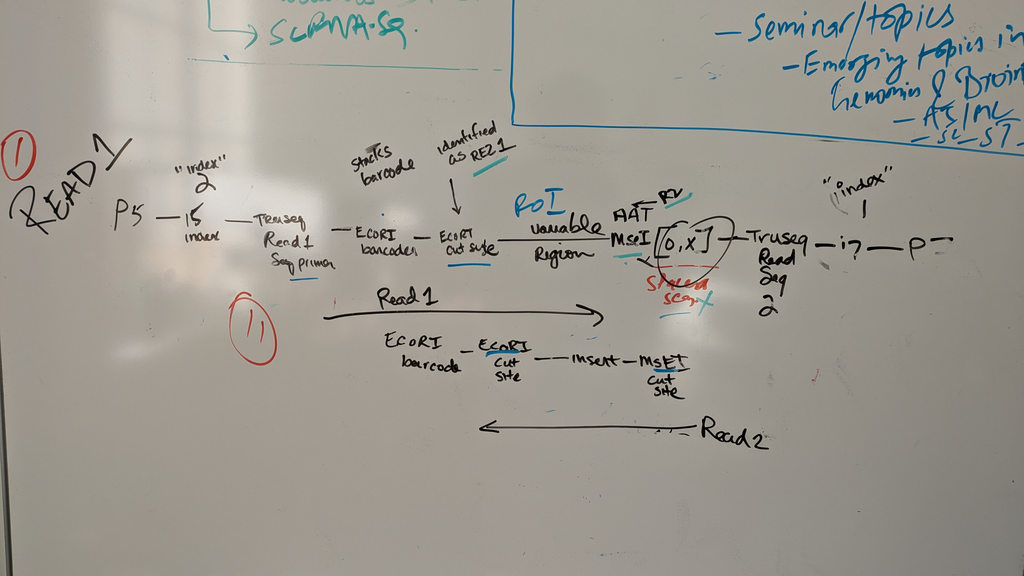

## 2.2 Bioinformatics Pipeline

All analyses were performed using the `env_radseq` conda environment unless otherwise noted. The pipeline followed these steps:

| Step | Tool | Description |
| --- | --- | --- |
| Spacer removal | cutadapt | Removed library-preparation spacer sequences from raw reads |
| Demultiplexing | process_radtags (Stacks) | Assigned reads to individual samples using inline barcodes |
| Quality assessment | FastQC + MultiQC | Evaluated read quality pre- and post-trimming |
| Read trimming | fastp | Adapter removal, quality trimming, and per-read filtering |
| Alignment | BWA-MEM + samtools | Aligned paired-end reads to the *M. edulis* reference genome (GCF_963676685.1_xbMytEdul2.2) |
| Read clipping & merge | GATK ClipReads + samtools merge | Hard-clipped reads and merged per-sample BAMs |
| Variant calling | bcftools mpileup + call | Called SNPs across all samples simultaneously |
| VCF filtering | VCFtools | Applied quality and missingness filters (see below) |
| Population stats | Stacks populations | Computed per-population summary statistics and pairwise F<sub>ST</sub> |
| Nucleotide diversity | pixy (`pixy` env) | Estimated π within populations |
| Structure analysis | fastSTRUCTURE (`structure` env) | Inferred population structure for K=1–15 |
| Downstream analysis | R (SNPRelate, triangulaR, vcfR) | PCA, hybrid index, diagnostic allele scoring |

The following diagram summarizes the complete workflow from raw reads through population genomic analyses.

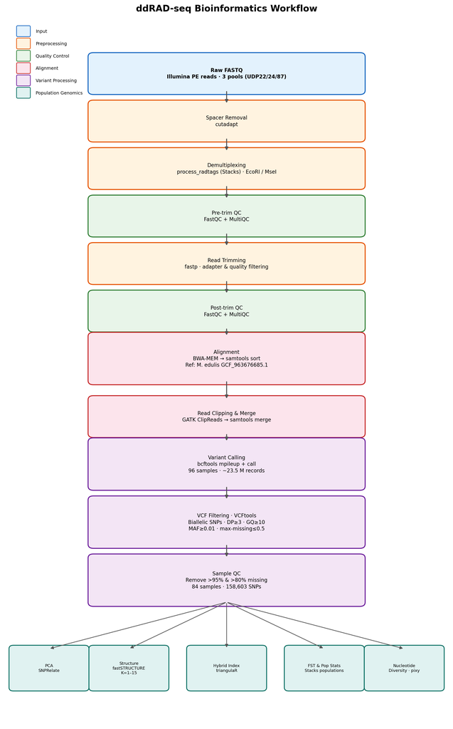

# 3. Quality Control

## 3.1 Pre-trimming QC

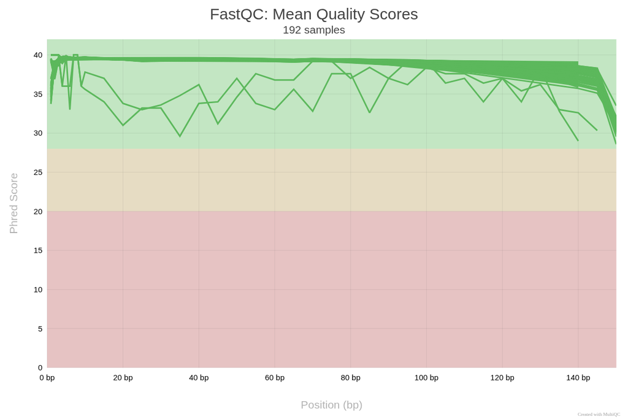

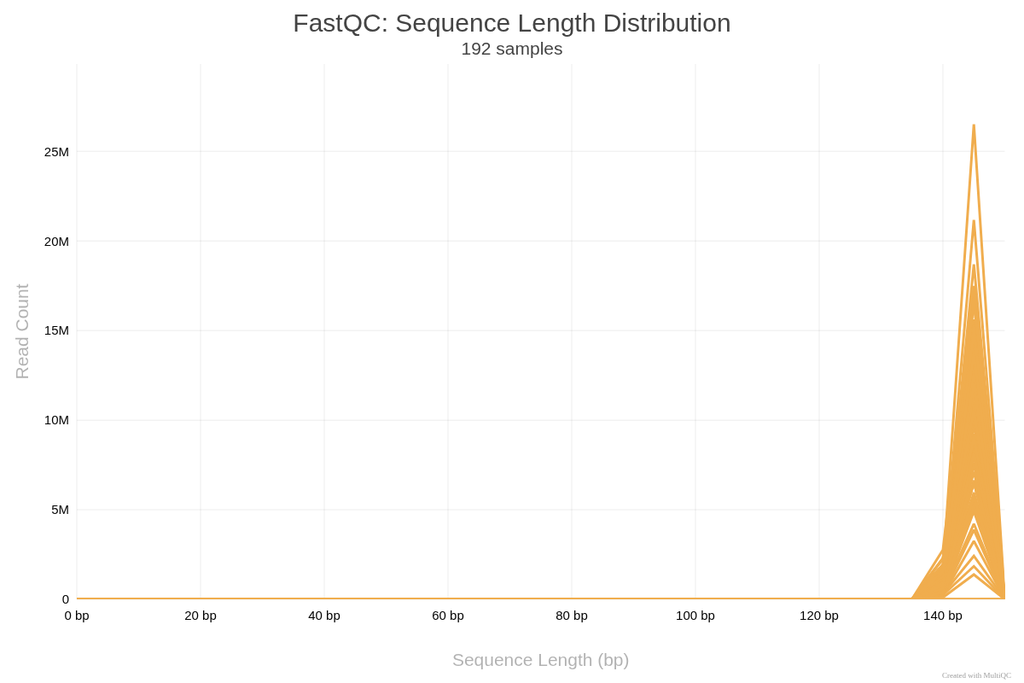

Please open the Pre-Trim MultiQC Report for the full interactive report. Key metrics from the pre-trim FastQC analysis are summarized below.

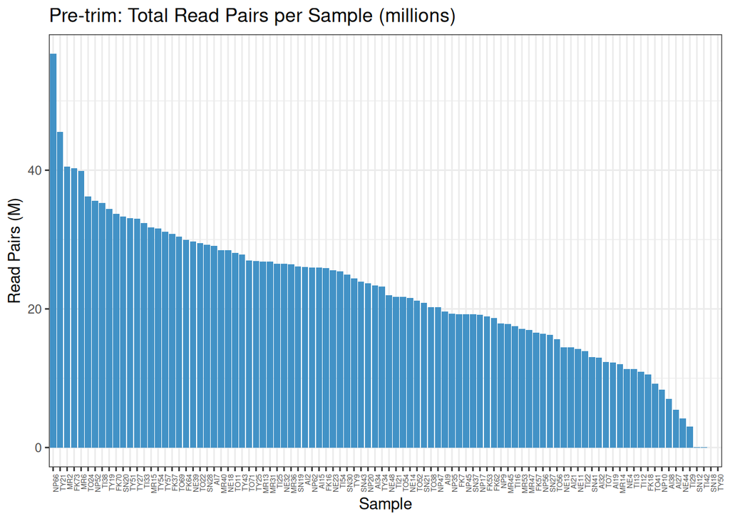

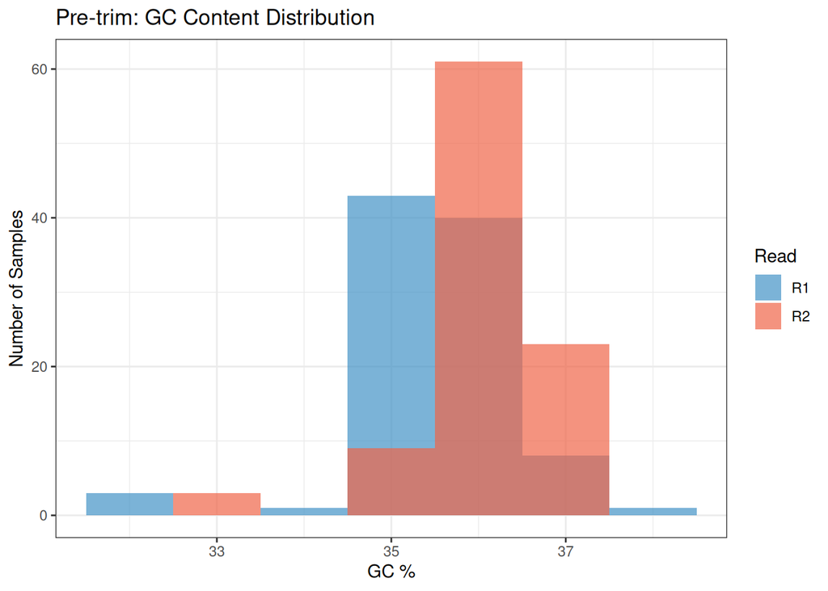

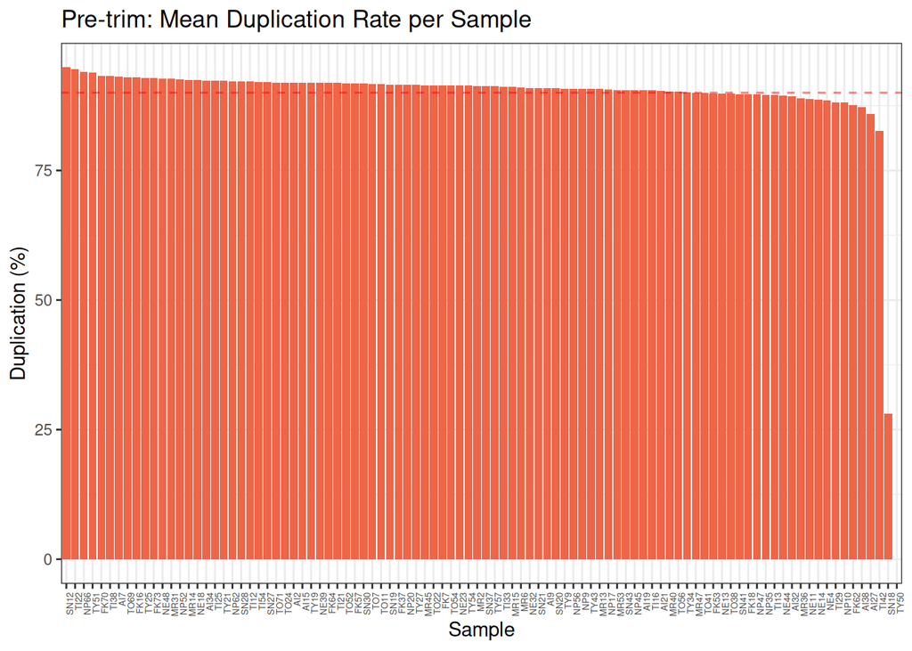

## 3.2 Post-trimming QC

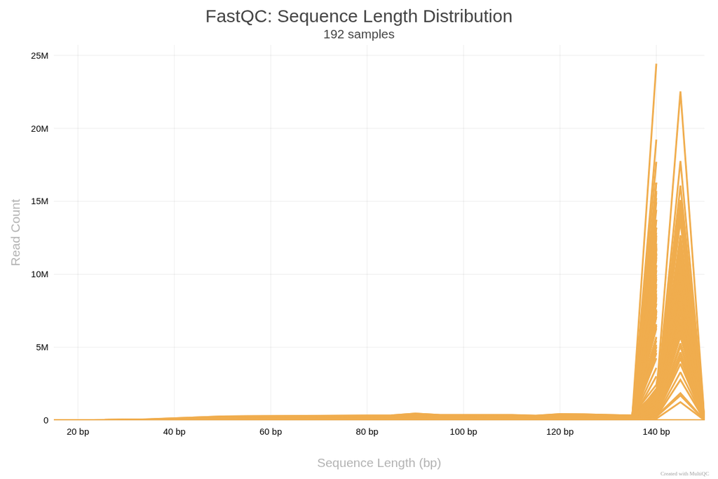

Please open the Post-Trim MultiQC Report for the full interactive report. Below we compare pre- and post-trimming read counts and quality metrics.

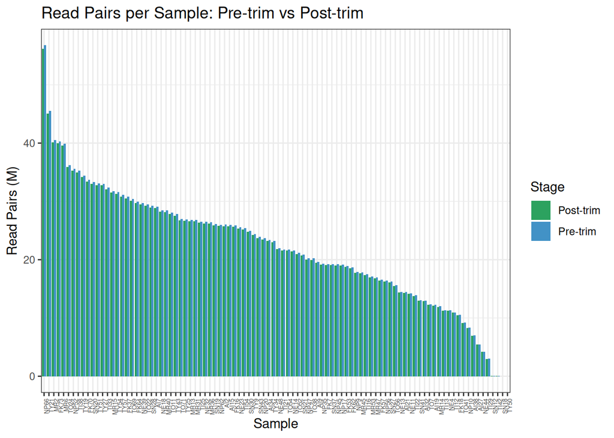

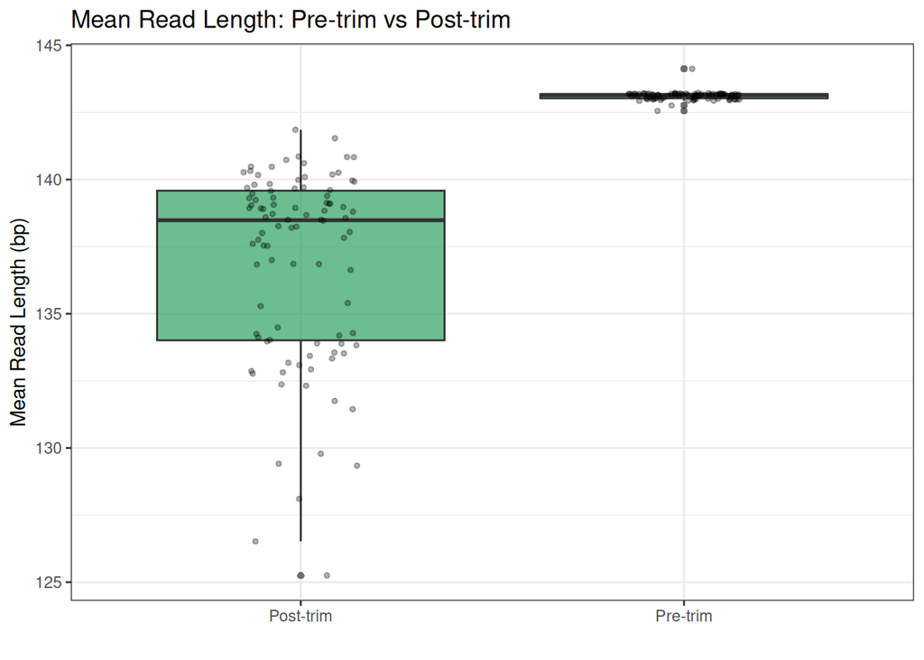

# 4. Alignment

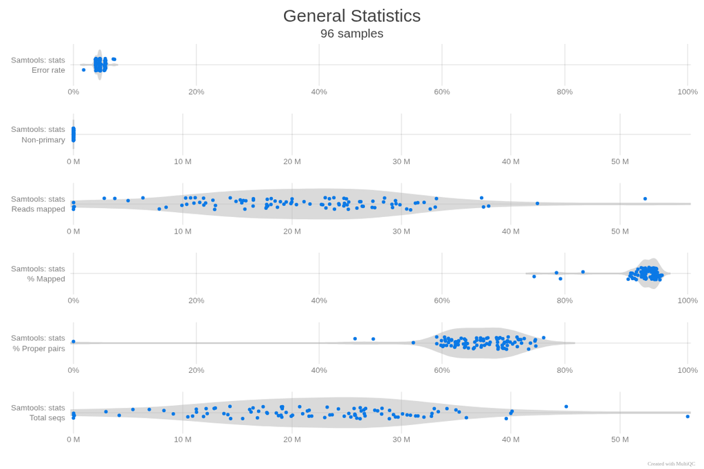

# 5. Variant Calling & Filtering

## 5.1 Variant Calling

Variants were called from the merged BAM file using `bcftools mpileup` (min mapping quality 20, min base quality 10) followed by `bcftools call` (diploid, multiallelic caller). The table below summarizes the raw variant calls before quality filtering.

Raw variant calling summary (bcftools mpileup + call)

| Metric | Value |
| --- | --- |
| Samples genotyped | 96 |
| Total variant records | 23,456,300 |
| SNPs | 22,464,340 |
| Indels | 991,960 |
| Multiallelic sites | 687,602 |
| Singleton SNPs | 3,507,288 |
| Ts/Tv ratio | 0.91 |

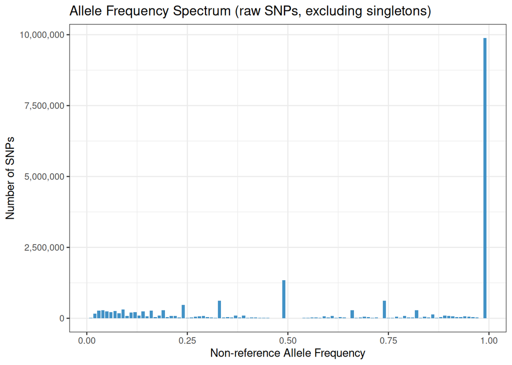

## 5.2 Variant Filtering

A multi-step filtering strategy was applied using VCFtools:

1. **Remove failed samples**: Individuals with >95% missing genotypes were excluded
2. **Quality filters**: Biallelic SNPs only; minimum depth (DP) ≥ 3; minimum genotype quality (GQ) ≥ 10; minor allele frequency (MAF) ≥ 0.01; indels removed; maximum missing rate per site ≤ 0.5
3. **Post-filter missingness**: Individuals with >80% missing genotypes in the filtered set were removed

Variant filtering summary

| Filtering Stage | Count |
| --- | --- |
| Raw variant records called | 23,456,300 |
| Samples sequenced | 96 |
| Samples removed (>95% missing) | 9 |
| Samples after initial filter | 87 |
| SNP sites after quality filtering | 158,603 |
| Samples removed (>80% missing post-filter) | 3 |
| Final samples retained | 84 |
| Final SNPs retained | 158,603 |

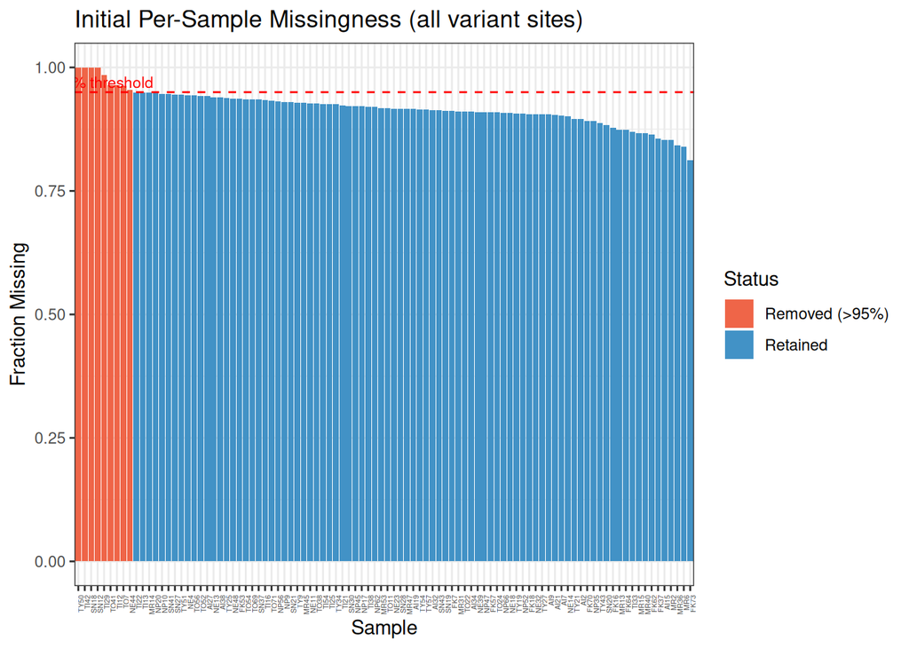

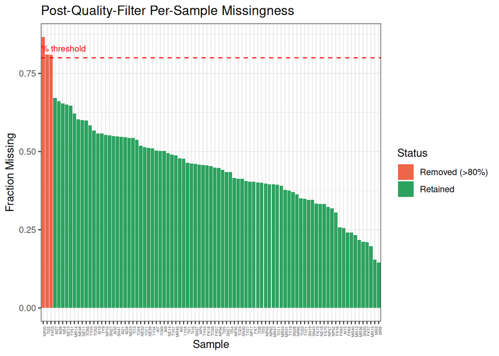

|  | Sample | Missing Rate | Status |
| --- | --- | --- | --- |
| 1 | NP20 | 0.8665 | Removed (&gt;80%) |
| 2 | TI22 | 0.8106 | Removed (&gt;80%) |
| 3 | FK53 | 0.8093 | Removed (&gt;80%) |
| 4 | AI27 | 0.6718 | Retained |
| 5 | AI38 | 0.6608 | Retained |
| 6 | NE4 | 0.6534 | Retained |
| 7 | NE13 | 0.6499 | Retained |
| 8 | TY51 | 0.6466 | Retained |
| 9 | MR14 | 0.6216 | Retained |
| 10 | NE48 | 0.6032 | Retained |

[output cut: 77 more lines]

# 6. Results

## 6.1 Principal Component Analysis (PCA)

PCA was performed on the filtered SNP dataset using SNPRelate. The plot below shows how individuals cluster in genomic space, colored by their prior 3-locus genotype classification and shaped by collection site.

PCA at missing.rate=0.3.

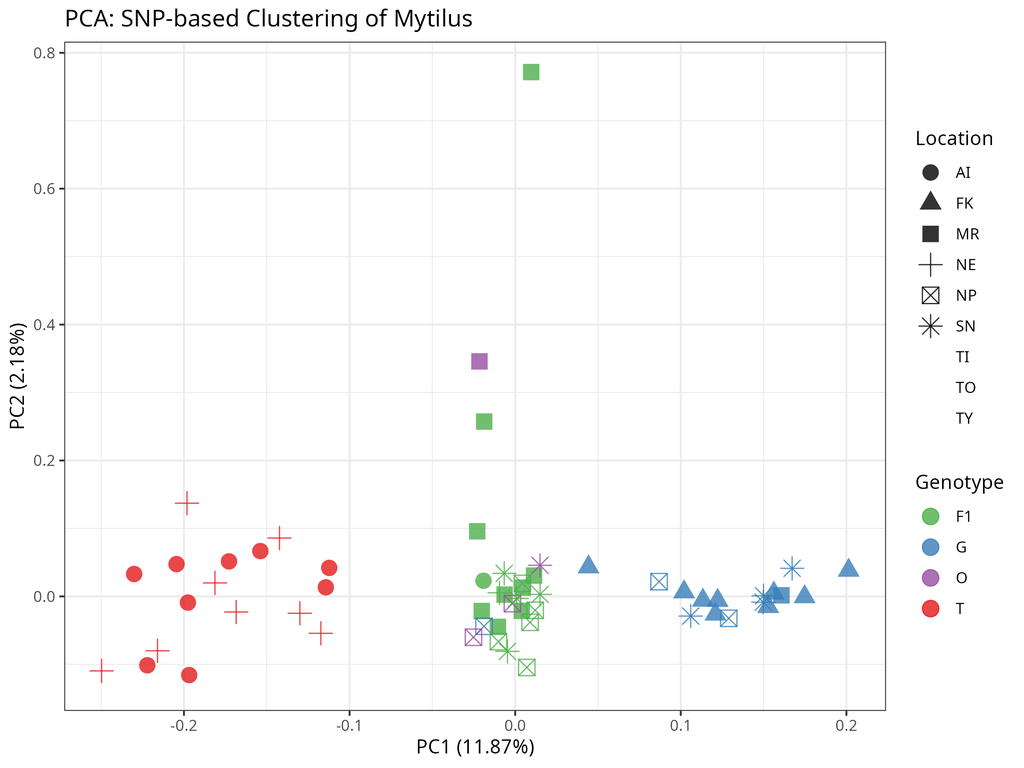

## 6.1.1 SNP-Based Phylogenetic Clustering

To complement PCA, we reconstructed a SNP-based hierarchical clustering tree using pairwise identity-by-state (IBS) distances (SNPRelate). This phylogenetic view supports the broad separation of parental G and T ancestry backgrounds while showing intermediate placements consistent with introgression.

[figure not shown]

## 6.2 Population Structure (Admixture)

### Model Selection

fastSTRUCTURE was run for K=1 through K=15 using variational Bayesian inference. The marginal likelihood for each K value is shown below to guide selection of the optimal number of ancestral populations.

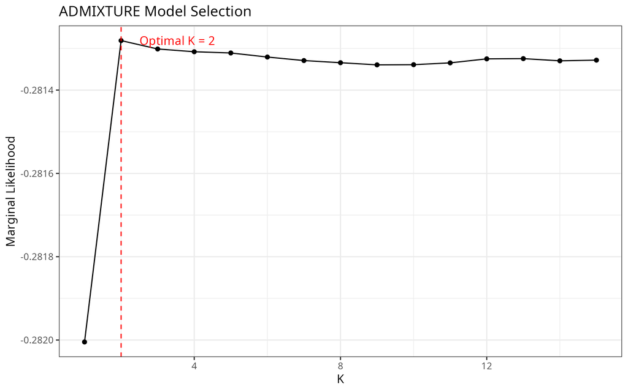

### Ancestry Proportions

Ancestry barplots for K=2 through K=4 are shown below, allowing comparison of clustering resolution across different assumed numbers of ancestral populations.

At K=2, ancestry proportions partition individuals into *M. galloprovincialis*-like and *M. trossulus*-like clusters. Barplots are faceted by collection site.

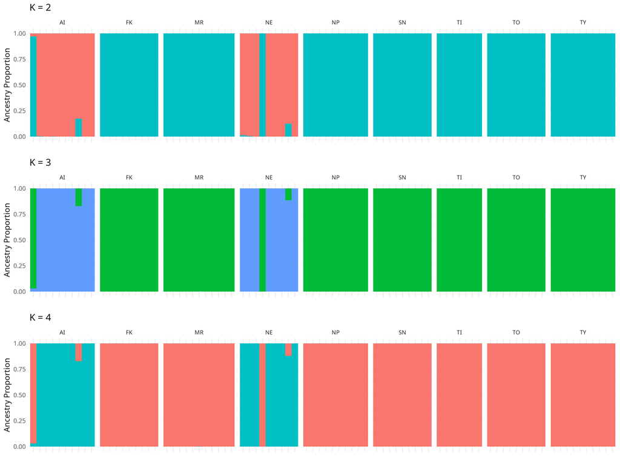

## 6.3 Hybrid Index Analysis

### Triangle Plot

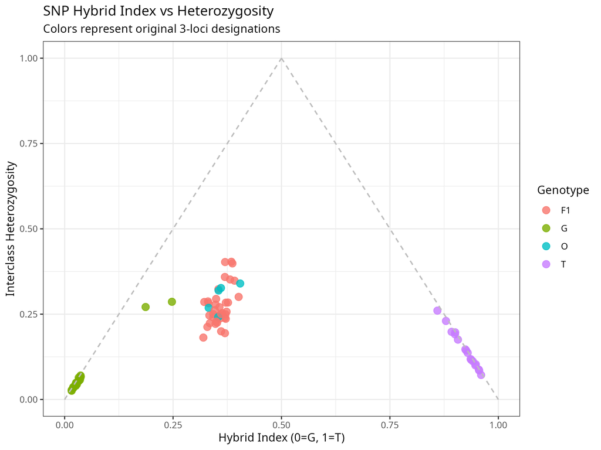

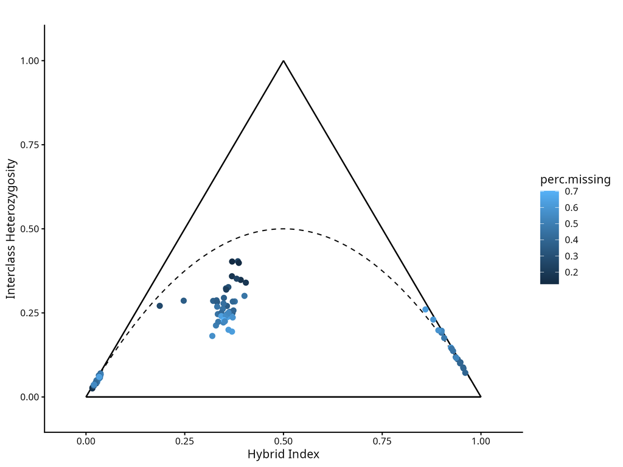

[figure not shown]

|  | Sample | Hybrid Index | Heterozygosity | Location | Genotype |
| --- | --- | --- | --- | --- | --- |
| 1 | AI15 | 0.3845 | 0.4035 | AI | F1 |
| 2 | AI19 | 0.9001 | 0.1909 | AI | T |
| 3 | AI21 | 0.9069 | 0.1753 | AI | T |
| 4 | AI27 | 0.924 | 0.1467 | AI | T |
| 5 | AI2 | 0.9411 | 0.1121 | AI | T |
| 6 | AI32 | 0.9361 | 0.1184 | AI | T |
| 7 | AI34 | 0.9293 | 0.1366 | AI | T |
| 8 | AI38 | 0.8595 | 0.2603 | AI | T |
| 9 | AI7 | 0.9481 | 0.103 | AI | T |
| 10 | AI9 | 0.955 | 0.0876 | AI | T |

[output cut: 74 more lines]

### Hybridization Summary by Site

Per-site hybridization summary. Hybrid index: 0 = pure M. galloprovincialis, 1 = pure M. trossulus.

| Location | N | Mean Hybrid Index | Proportion Hybrids |
| --- | --- | --- | --- |
| AI | 10 | 0.8685 | 0.2000 |
| FK | 9 | 0.0459 | 0.1111 |
| MR | 11 | 0.3438 | 0.9091 |
| NE | 9 | 0.8614 | 0.3333 |
| NP | 10 | 0.2737 | 0.8000 |
| SN | 9 | 0.2024 | 0.5556 |
| TI | 7 | 0.1185 | 0.2857 |
| TO | 9 | 0.2860 | 0.7778 |
| TY | 10 | 0.3224 | 0.9000 |

## 6.4 Diagnostic Allele Analysis

Species-diagnostic SNPs (allele frequency difference >= 0.8 between reference G and T groups) were identified using triangulaR. Each individual was scored at these loci to estimate the proportion of *M. galloprovincialis* vs. *M. trossulus* alleles.

Because G/T metadata labels were swapped during workflow updates, the diagnostic pipeline now applies an orientation check before final class assignment. This prevents reporting SNP classes in the opposite direction and keeps the per-individual diagnostic table consistent with the current label convention.

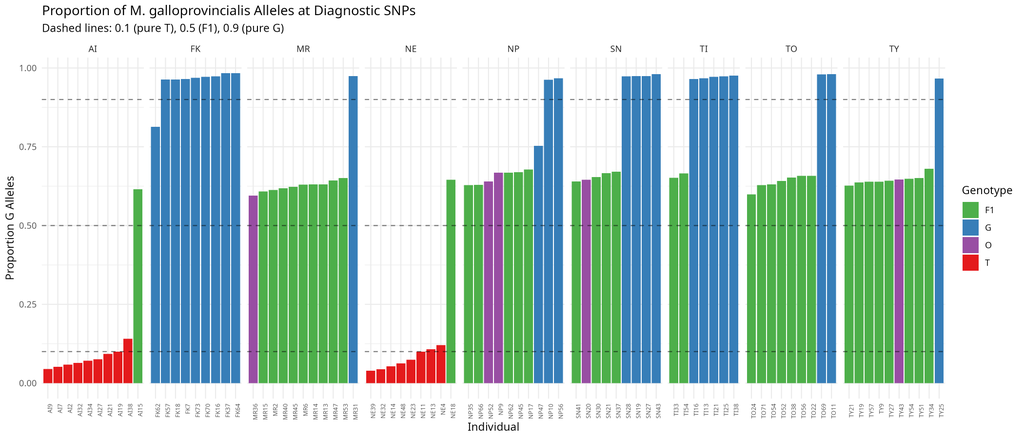

*Figure note: SNP-based diagnostic classes in this run are 45 Backcross/Introgressed, 23 Pure G, 14 Pure T, and 2 F1-like (N = 84 individuals).*

|  | Sample | G Allele Prop | T Allele Prop | N Diag. Loci | Location | 3-Locus Genotype | SNP Class |
| --- | --- | --- | --- | --- | --- | --- | --- |
| 1 | AI15 | 0.6155 | 0.3845 | 2922 | AI | F1 | Backcross/Introgressed |
| 2 | AI38 | 0.1405 | 0.8595 | 1452 | AI | T | Backcross/Introgressed |
| 3 | AI19 | 0.0999 | 0.9001 | 2032 | AI | T | Pure T |
| 4 | AI21 | 0.0931 | 0.9069 | 2019 | AI | T | Pure T |
| 5 | AI27 | 0.076 | 0.924 | 1506 | AI | T | Pure T |
| 6 | AI34 | 0.0707 | 0.9293 | 2137 | AI | T | Pure T |
| 7 | AI32 | 0.0639 | 0.9361 | 2128 | AI | T | Pure T |
| 8 | AI2 | 0.0589 | 0.9411 | 2471 | AI | T | Pure T |
| 9 | AI7 | 0.0519 | 0.9481 | 2427 | AI | T | Pure T |
| 10 | AI9 | 0.045 | 0.955 | 2454 | AI | T | Pure T |

[output cut: 74 more lines]

## 6.5 Pairwise F<sub>ST</sub>

Pairwise F<sub>ST</sub> values were computed between genotype groups (G, T, F1, O) using the Stacks `populations` module. Higher F<sub>ST</sub> between G and T confirms species-level divergence.

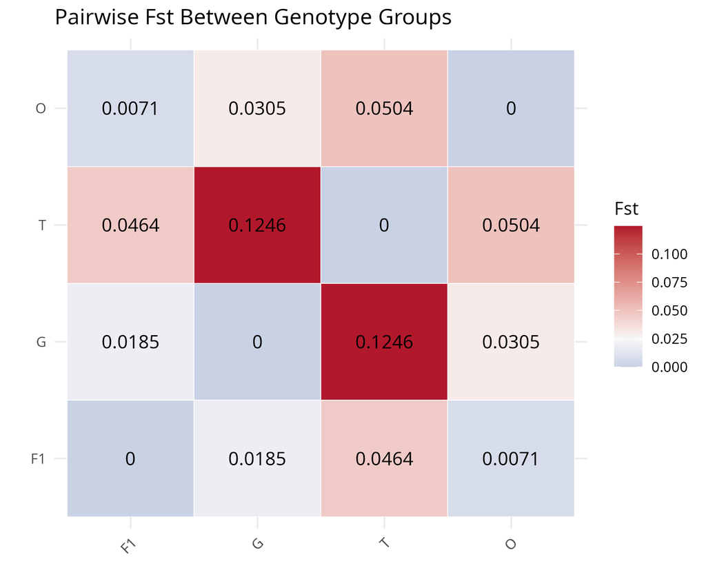

Pairwise Fst values between genotype groups

|  | F1 | G | T | O |
| --- | --- | --- | --- | --- |
| F1 | 0.0000 | 0.0185 | 0.0464 | 0.0071 |
| G | 0.0185 | 0.0000 | 0.1246 | 0.0305 |
| T | 0.0464 | 0.1246 | 0.0000 | 0.0504 |
| O | 0.0071 | 0.0305 | 0.0504 | 0.0000 |

## 6.6 Population Summary Statistics

Summary statistics from the Stacks `populations` module for each genotype group, including number of private alleles, observed heterozygosity, expected heterozygosity, nucleotide diversity (π), and inbreeding coefficient (F<sub>IS</sub>).

Per-group population summary statistics (variant positions)

| Group | Private Alleles | Mean N | Obs. Het | Exp. Het | π | F_IS |
| --- | --- | --- | --- | --- | --- | --- |
| F1 | 25227 | 21.7 | 0.0863 | 0.1203 | 0.1232 | 0.1447 |
| G | 16049 | 15.0 | 0.0849 | 0.0965 | 0.1017 | 0.0590 |
| T | 13950 | 8.9 | 0.1512 | 0.1255 | 0.1476 | 0.0042 |
| O | 3486 | 3.4 | 0.0892 | 0.1007 | 0.1206 | 0.0621 |

## 6.7 Individual Heterozygosity

Per-individual observed vs. expected homozygosity and the inbreeding coefficient (F) computed by VCFtools.

|  | Sample | Obs. Hom. | Exp. Hom. | N Sites | F | Location | Genotype |
| --- | --- | --- | --- | --- | --- | --- | --- |
| 1 | AI15 | 99377 | 99757.1 | 114412 | -0.0259 | AI | F1 |
| 2 | AI19 | 58444 | 58795.5 | 67733 | -0.0393 | AI | T |
| 3 | AI2 | 70028 | 69394.3 | 79998 | 0.0598 | AI | T |
| 4 | AI21 | 60012 | 60247.9 | 69382 | -0.0258 | AI | T |
| 5 | AI27 | 44774 | 43730.4 | 50311 | 0.1586 | AI | T |
| 6 | AI32 | 61276 | 59906.5 | 68983 | 0.1509 | AI | T |
| 7 | AI34 | 61415 | 60382.7 | 69630 | 0.1116 | AI | T |
| 8 | AI38 | 45881 | 45199 | 51996 | 0.1003 | AI | T |
| 9 | AI7 | 66885 | 65962.6 | 76023 | 0.0917 | AI | T |
| 10 | AI9 | 68099 | 66230.9 | 76321 | 0.1851 | AI | T |

[output cut: 74 more lines]

# 7. Conclusions

## Key Findings

1. **Final dataset**: After quality filtering, **84 individuals** and **158,603 biallelic SNPs** were retained for downstream analysis.
2. **Clear species differentiation**: PCA, admixture, and F<sub>ST</sub> all support genomic separation between the two parental groups. Pairwise F<sub>ST</sub> between G and T remains high (0.1246), consistent with substantial divergence.
3. **Hybridization is widespread but uneven across sites**: Site-level hybrid proportions are highest at **MR (0.9091)** and **TY (0.9000)**, followed by NP (0.8000) and TO (0.7778), while FK shows the lowest hybrid proportion (0.1111).
4. **Diagnostic SNP classification (current run)**: Across 84 individuals, SNP classes are **45 Backcross/Introgressed**, **23 Pure G**, **14 Pure T**, and **2 F1-like**. Most prior F1-designated samples fall in the Backcross/Introgressed class, indicating more complex introgression than simple first-generation hybridization.
5. **Directionality check prevents label inversion**: The diagnostic allele workflow applies an orientation check (with automatic flipping when needed) so SNP-based classes are not reported in reverse when metadata G/T labels are swapped.

## Deliverables

**Box Folder:** https://notredame.app.box.com/folder/366006009250?s=9ffpwjairhkyn5ywu0z9k0fi2tgyokce

| File | Description |
| --- | --- |
| `raw/` | Raw sequencing data (FASTQ files, barcodes, sample metadata) |
| `results/multiqc_PreTrim/multiqc_report_PreTrim.html` | Pre-trimming QC report |
| `results/multiqc_trimmed/multiqc_report_PostTrim.html` | Post-trimming QC report |
| `results/SNP_call/merged.vcf.gz` |  |
| `results/filtered_SNPs/merged_final.vcf.gz` | Final filtered VCF (84 samples, 158,603 SNPs) |
| `results/populations/` | Stacks populations output (F<sub>ST</sub>, summary stats) |
| `results/admixture/` | fastSTRUCTURE results (K=1-15) |
| `results/downstream_plots/` | All figures and data tables (PCA, triangle, admixture, F<sub>ST</sub>, diagnostics) |

Workflow scripts on GitHub: https://github.com/GBCF-Bioinformatics-ND/ddRADSeq_workflow_2026

*Analysis performed by the Genomics & Bioinformatics Core Facility (GBCF), University of Notre Dame.*